# Emotion Detection in Tweets

December 12, 2019

## Introduction

**Background**: Emotional detection is effective in mining public opinions towards certain topics

**Goal**:

- Investigate representative vocabularies in emotional tweets
- Build model to detect emotion from social media text

**Dataset**: Emotion Intensity Dataset (2017): 7102 tweets annotated with emotion and intensity score

#### Example Tweets

|  | tweets | label | intensity |
| --- | --- | --- | --- |
| 2007 | Been waiting all week for this game ❤️❤️❤️ #cheer #friday ❤️ | joy | 0.940 |
| 1 | How the fu*k! Who the heck! moved my fridge!… should I knock the landlord door. #angry #mad ## | anger | 0.938 |
| 1838 | @STLouis_RamsFan their whole team is limited when they’re on the field. #terrible | fear | 0.271 |
| 3459 | Just put the winter duvet on ☃️❄️🌬☔️ #serious | sadness | 0.312 |

## Preprocessing

- Convert all characters in each tweet to lower case
- Remove punctuations, blank spaces, and special characters
  - Keep “#” for mining hashtags
- Create a new column containing all hashtags in each tweet

#### Example Preprocessed Tweets

|  | tweets | hashtags | label | intensity |
| --- | --- | --- | --- | --- |
| 2007 | been waiting all week game #cheer #friday | #cheer #friday | joy | 0.940 |
| 1 | how fuk who heck moved fridge should knock landlord door #angry #mad | #angry #mad | anger | 0.938 |
| 1838 | whole team limited when theyre on field #terrible | #terrible | fear | 0.271 |
| 3459 | just put winter duvet on #serious | #serious | sadness | 0.312 |

## Mining Top Emotional Words & Hashtags

- Two sample t-test was performed
  - Word distribution in tweets of a specific category vs not of a specific category
  - Bigger t-statistic value = more representative
- Using the test, find top positive and negative words/hashtags

#### Partial Code

```r
  summ = matrix(0, nrow = vocab_size, ncol=4)
  summ[,1] = colapply_simple_triplet_matrix(as.simple_triplet_matrix(dtm[emotion==label, ]),mean)
  summ[,2] = colapply_simple_triplet_matrix(as.simple_triplet_matrix(dtm[emotion==label, ]),var)
  summ[,3] = colapply_simple_triplet_matrix(as.simple_triplet_matrix(dtm[emotion!=label, ]),mean)
  summ[,4] = colapply_simple_triplet_matrix(as.simple_triplet_matrix(dtm[emotion!=label, ]),var)
  n1 =sum(emotion==label);
  n =length(emotion)
  n0 = n - n1
  scores = (summ[,1] - summ[,3])/sqrt(summ[,2]/n1 + summ[,4]/n0)
```

## Visualization of Emotional Words & Hashtags

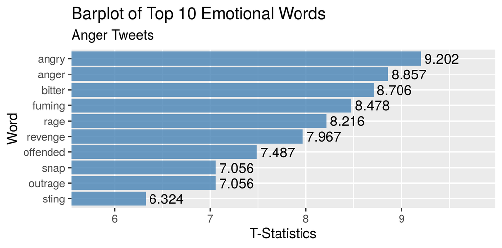

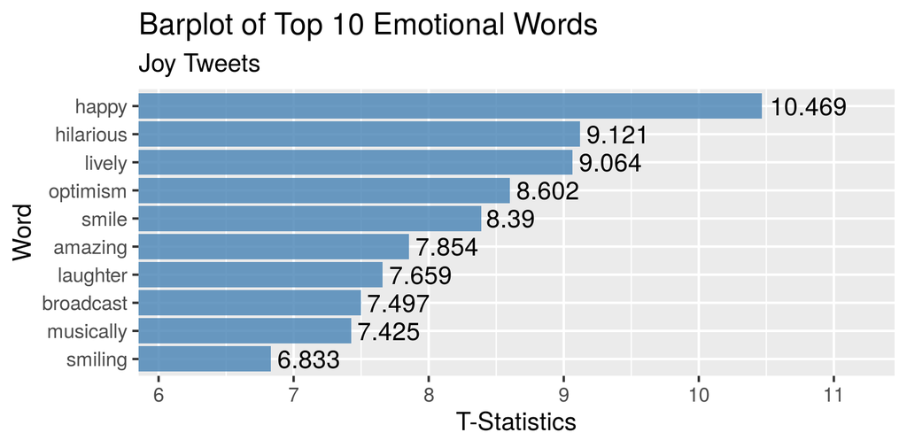

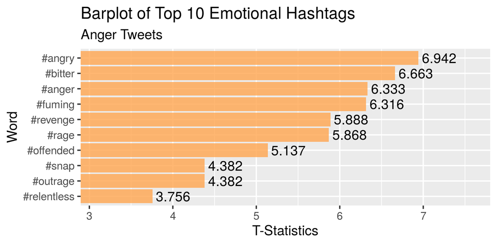

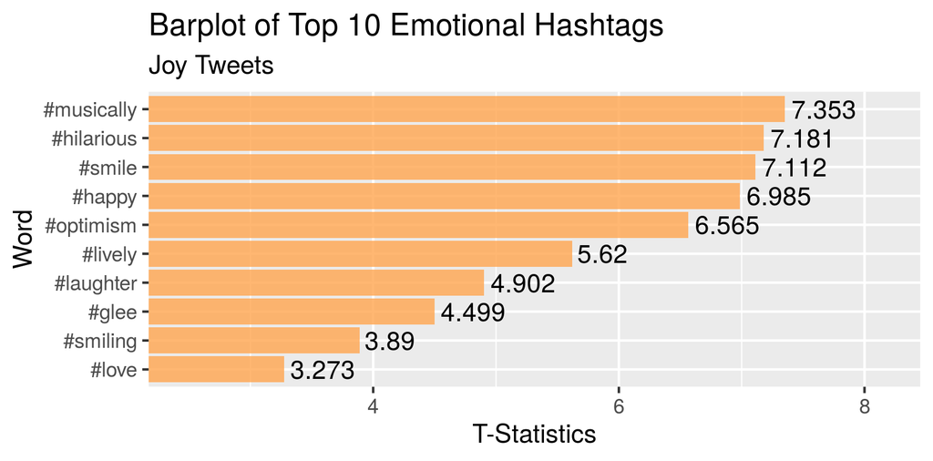

## Emotion Prediction Model

- Using “fastrtext” package, we first obtained vector representation for each tweet
- Vector-label pairs obtained will be used as our training data
- Use XGBoost to train our model
- Achieved ~0.5 F1-score for “anger”, “fear”, “joy” and ~0.34 F1-score for “sadness”
- Confusion matrix shown below

```
## Confusion Matrix and Statistics
##
##           Reference
## Prediction   0   1   2   3
##          0 160  91  37  58
##          1  67 265  60  59
##          2  33  60 173  46
##          3  54 102  57  99
##
## Overall Statistics
##
##                Accuracy : 0.4905
##                  95% CI : (0.4642, 0.5168)
##     No Information Rate : 0.3645
##     P-Value [Acc > NIR] : < 2e-16
##
##                   Kappa : 0.311
##
##  Mcnemar's Test P-Value : 0.01055
##
## Statistics by Class:
##
##                      Class: 0 Class: 1 Class: 2 Class: 3
## Precision              0.4624   0.5876   0.5545  0.31731
## Recall                 0.5096   0.5116   0.5291  0.37786
## F1                     0.4848   0.5470   0.5415  0.34495
## Prevalence             0.2210   0.3645   0.2301  0.18438
## Detection Rate         0.1126   0.1865   0.1217  0.06967
## Detection Prevalence   0.2435   0.3174   0.2196  0.21956
## Balanced Accuracy      0.6708   0.6528   0.7010  0.59704
```

## Word Cloud Visualization

- Created a word cloud from preprocessed tweets to better visualize the vocabularies used in emotional tweets
  - Frequency of the words are represented by size and color
  - Limited maximum number of words to 100

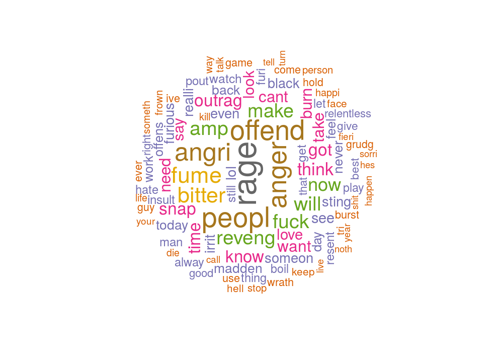

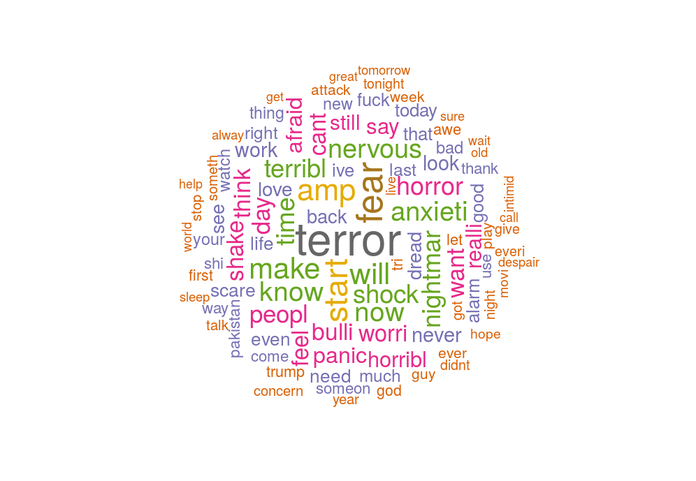